# Multivariate statistics

Homeworks - correction

Samuel Orso

2017-11-07

# Introduction: Multivariate regression

**Exercise 1:**

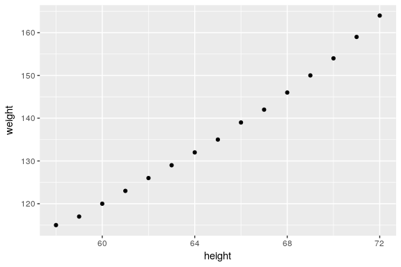

```r
# to load the data
# data(women)

# see the dataset
# women

# read explanations about the dataset
# ?women

# 3. Plot
require(ggplot2)
ggplot(women, aes(x = height, y = weight)) +
  geom_point()
```

```r
# 5. Fit the regression
fit_lm <- lm(weight ~ height, data = women)

# 6. Summary
summary(fit_lm)
```

```
##
## Call:
## lm(formula = weight ~ height, data = women)
##
## Residuals:
##     Min      1Q  Median      3Q     Max
## -1.7333 -1.1333 -0.3833  0.7417  3.1167
##
## Coefficients:
##              Estimate Std. Error t value Pr(>|t|)
## (Intercept) -87.51667    5.93694  -14.74 1.71e-09 ***
## height        3.45000    0.09114   37.85 1.09e-14 ***
## ---
## Signif. codes:  0 '***' 0.001 '**' 0.01 '*' 0.05 '.' 0.1 ' ' 1
##
## Residual standard error: 1.525 on 13 degrees of freedom
## Multiple R-squared:  0.991,  Adjusted R-squared:  0.9903
## F-statistic:  1433 on 1 and 13 DF,  p-value: 1.091e-14
```

```r
# 7. Change of unit using grid package (install it befor)
# install.package("grid")
require(grid)
new_x <- convertX(unit(173,"cm"),"inches")

# predict using R code, by hand is ok
predict(fit_lm,newdata = data.frame(height = as.numeric(new_x)))
```

```
##        1
## 147.4636
```

4. The regression equation is
   $$\text{weight}_i = \beta_0 + \beta_1 \text{height}_i + \varepsilon_i,\quad i = 1,\dots,15.$$
5. The estimated regression equation is
   $$\widehat{\text{weight}}_i = -87.52 + 3.45\; \text{height}_i,\quad i = 1,\dots,15.$$
6. We simply replace the new *Height* in the estimated regression equation to obtain the predicted weight $\widehat{\text{weight}}^{\text{new}}$. The new *Height* needs to be changed to the right unit (from meters to inches). 173 cm is about 68.11 inches (see `R` code). We thus have
   $$\widehat{\text{weight}}^{\text{new}} = -87.52 + 3.45\; \text{height}^{\text{new}} \approx 147.46.$$

# Descriptive analysis

**Exercise 2**

```r
# 1.
# set the workind directoy (for me)
setwd("~/Documents/Teaching/RM/")

# to load the data
ski <- read.csv(file = "ski.csv", header = TRUE, sep = ";")

# see the dataset
head(ski)
```

| Temperature | Tickets |
| --- | --- |
| 14 | 472 |
| -10 | 442 |
| 33 | 607 |
| 11 | 577 |
| 7 | 520 |
| -12 | 419 |

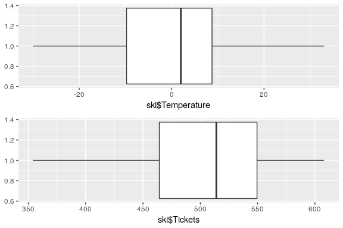

```r
# 2.
# load the ggplot2 package for plots
require(ggplot2)
require(gridExtra)
plot1 <- qplot(ski$Temperature, x=1, geom = "boxplot") + xlab(NULL) + coord_flip()
plot2 <- qplot(ski$Tickets, x=1, geom = "boxplot") + xlab(NULL) + coord_flip()
grid.arrange(plot1, plot2, ncol=1)
```

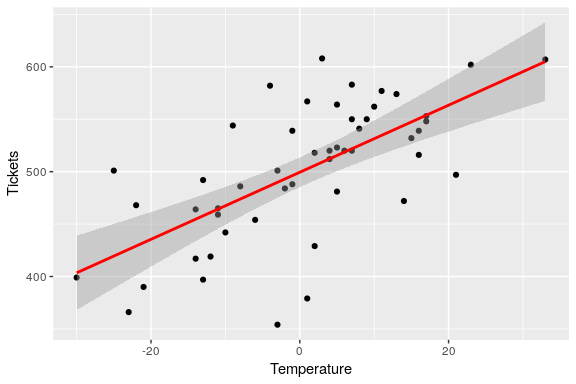

```r
# 3.
ggplot(data = ski, aes(x = Temperature, y = Tickets)) +
  geom_point() +
  stat_smooth(method = "lm", col = "red")
```

```r
# 4.
cor(ski)
```

```
##             Temperature  Tickets
## Temperature    1.000000 0.657018
## Tickets        0.657018 1.000000
```

```r
cor(ski, method = "spearman")
```

```
##             Temperature   Tickets
## Temperature   1.0000000 0.6664024
## Tickets       0.6664024 1.0000000
```

```r
# Both linear and Spearman's correlation are very close numerically.
# It does not seem to have outliers. Also on the boxplots and scatterplot,
# no points seem to be outliers.

# 5.
fit_lm <- lm(Tickets ~ Temperature, data = ski)
summary(fit_lm)
```

```
##
## Call:
## lm(formula = Tickets ~ Temperature, data = ski)
##
## Residuals:
##     Min      1Q  Median      3Q     Max
## -135.84  -26.05    1.06   30.18   98.97
##
## Coefficients:
##             Estimate Std. Error t value Pr(>|t|)
## (Intercept) 499.4366     7.0402  70.940  < 2e-16 ***
## Temperature   3.1988     0.5298   6.038 2.19e-07 ***
## ---
## Signif. codes:  0 '***' 0.001 '**' 0.01 '*' 0.05 '.' 0.1 ' ' 1
##
## Residual standard error: 49.74 on 48 degrees of freedom
## Multiple R-squared:  0.4317, Adjusted R-squared:  0.4198
## F-statistic: 36.46 on 1 and 48 DF,  p-value: 2.193e-07
```

```r
# 7.
predict(fit_lm, newdata = data.frame(Temperature = -2.5))
```

```
##        1
## 491.4395
```

6. The estimated regression equation is
   $$\widehat{\text{Tickets}}_i = 499.44 + 3.2 \;\text{Temperature}_i,\quad i = 1,\dots,50$$
   or equivalently you can write
   $$\hat{y}_i = 499.44 + 3.2 \;x_i,\quad i = 1,\dots,50$$

# Inference

**Exercise 3:**

```r
# set the workind directoy (for me)
setwd("~/Documents/Teaching/RM/")

# to load the data
hospital <- read.csv(file = "hospital.csv", header = TRUE, sep = ";")

# see the dataset
head(hospital)
```

| Patient | Days |
| --- | --- |
| 1 | 1 |
| 2 | 1 |
| 3 | 1 |
| 4 | 1 |
| 5 | 2 |
| 6 | 2 |

```r
# We need the average and the standard deviation
mean(hospital$Days)
```

```
## [1] 1.386364
```

```r
sd(hospital$Days)
```

```
## [1] 0.5793304
```

```r
# We can also compute the quantiles (or use the tables)
qnorm(.975)
```

```
## [1] 1.959964
```

```r
qnorm(.95)
```

```
## [1] 1.644854
```

```r
qt(.975, df = 43)
```

```
## [1] 2.016692
```

```r
qt(.95, df = 43)
```

```
## [1] 1.681071
```

2. We have $\bar{x} = 1.3864$ and the quantile $z_{0.975} = 1.96$. The 95% confidence interval is therefore
   $$\text{CI}(\bar{x},95\%) = [1.3864 - 1.96/\sqrt{44};\; 1.3864 + 1.96/\sqrt{44}] = [1.0909;\;1.6819]$$
3. The standard deviation is estimated at $\hat{\sigma}\approx 0.5793$ and the quantile $t_{43;\;0.975} = 2.0167$. The 95% confidence interval is therefore
   $$\text{CI}(\bar{x},95\%) = [1.3864 - 2.0167\;0.5793/\sqrt{44};\; 1.3864 + 2.0167\;0.5793 /\sqrt{44}] = [1.2103;\;1.5625]$$
4. Clearly if the confidence level decreases, there is a lower probability that the confidence interval will contain the true value, it translates into a shorter interval. The quantiles are modifies as follows $z_{0.95} = 1.6449$ and $t_{43;\;0.95} = 1.6811$. The new confidence intervals are
   $$\text{CI}(\bar{x},90\%) = [1.3864 - 1.6449/\sqrt{44};\; 1.3864 + 1.6449/\sqrt{44}] = [1.1384;\;1.6344]$$
   and
   $$\text{CI}(\bar{x},90\%) = [1.3864 - 1.6811\;0.5793/\sqrt{44};\; 1.3864 + 1.6811\;0.5793 /\sqrt{44}] = [1.2396;\;1.5332]$$

**Exercise 4:**

```r
# 1.
# set the workind directoy (for me)
setwd("~/Documents/Teaching/RM/")

# to load the data
wt <- read.csv(file = "waiting_time.csv", header = TRUE, sep = ";")

# see the dataset
head(wt)
```

| When | Time |
| --- | --- |
| Before | 186 |
| Before | 156 |
| Before | 142 |
| Before | 136 |
| Before | 125 |
| Before | 195 |

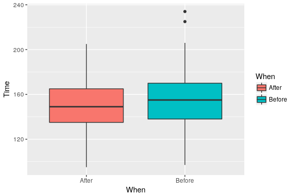

```r
# Descriptive analysis
require(ggplot2)
require(dplyr)

ggplot(wt, aes(y = Time, x = When, group = When, fill = When)) +
  geom_boxplot()
```

```r
wt %>% group_by(When) %>% summarise(n = length(Time), average = mean(Time), median = median(Time),
                                    max = max(Time), min = min(Time), variance = var(Time))
```

| When | n | average | median | max | min | variance |
| --- | --- | --- | --- | --- | --- | --- |
| After | 213 | 149.8498 | 149 | 205 | 95 | 476.1000 |
| Before | 202 | 154.4307 | 155 | 234 | 97 | 558.9131 |

```r
# 3.
t.test(Time ~ When, mu = 0, alternative = "less", data = wt)
```

```
##
##  Welch Two Sample t-test
##
## data:  Time by When
## t = -2.0482, df = 405.82, p-value = 0.02059
## alternative hypothesis: true difference in means is less than 0
## 95 percent confidence interval:
##        -Inf -0.8937312
## sample estimates:
##  mean in group After mean in group Before
##             149.8498             154.4307
```

```r
# 4.
# t.test(Time ~ When, mu = 0, alternative = "less", data = wt, paired = TRUE)

# 5.
wilcox.test(Time ~ When, mu = 0, alternative = "less", data = wt)
```

```
##
##  Wilcoxon rank sum test with continuity correction
##
## data:  Time by When
## W = 19004, p-value = 0.01998
## alternative hypothesis: true location shift is less than 0
```

2. It is not clear from the description that we have the exact same clients before/after the change of process. Somehow, it would make more sense to have different clients. Additionnaly,from the descriptive analysis, we can see that the number of clients is inequal. A $t$-test for two different means seems more adequate. Since we are expecting a decrease in waiting time after the change, we should orientate the alternative hypothesis. We make the following hypothesis:
   $$H_0:\mu_{\text{Before}} = \mu_{\text{After}}$$
   agains
   $$H_1: \mu_{\text{Before}} > \mu_{\text{After}}$$
   Since there are no indications, we take a default significance level of $\alpha=5\%$.
3. Based on the sample and a level of $\alpha=5\%$, we reject $H_0$. We conclude the waiting time decreased significantly after the change of process.
4. As already mentionned, the number of unit is different between after/before, so a paired $t$-test is not possible.
5. On the boxplot we can see two potential outliers that may influence the mean of the groupe before. This influence may bias the $p$-value towards rejecting the null. The $t$-test and Wilcoxon test do not contradict each, both reject $H_0$ at level of significance of 5%.

**Exercise 5:**

```r
# 1.
# set the workind directoy (for me)
setwd("~/Documents/Teaching/RM/")

# to load the data
media <- read.csv(file = "medias.csv", header = TRUE, sep = ";")

# see the dataset
head(media)
```

| Media | Impact |
| --- | --- |
| Newspaper | 24.39 |
| Newspaper | 22.68 |
| Newspaper | 22.67 |
| Newspaper | 23.95 |
| Newspaper | 22.33 |
| Newspaper | 22.25 |

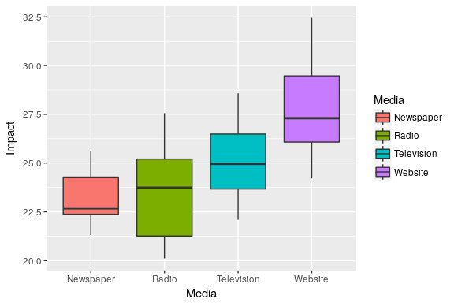

```r
# Descriptive analysis
require(ggplot2)
require(dplyr)

ggplot(media, aes(y = Impact, x = Media, group = Media, fill = Media)) +
  geom_boxplot()
```

```r
tbl <- media %>% group_by(Media) %>% summarise(n = length(Impact), average = mean(Impact), variance = var(Impact))
tbl
```

| Media | n | average | variance |
| --- | --- | --- | --- |
| Newspaper | 10 | 23.209 | 1.722077 |
| Radio | 10 | 23.609 | 7.131766 |
| Television | 10 | 25.106 | 4.142382 |
| Website | 10 | 27.729 | 6.896766 |

```r
# 3.
(avg_overall <- mean(media$Impact))
```

```
## [1] 24.91325
```

```r
(ss_total <- sum((media$Impact- avg_overall)^2))
```

```
## [1] 304.7483
```

```r
(ss_treat <- sum(tbl$n * (tbl$average - avg_overall)^2))
```

```
## [1] 125.7114
```

```r
(ss_res <- ss_total - ss_treat)
```

```
## [1] 179.0369
```

```r
# 4.
anova_test <- aov(Impact ~ Media, data = media)
summary(anova_test)
```

```
##             Df Sum Sq Mean Sq F value   Pr(>F)
## Media        3  125.7   41.90   8.426 0.000226 ***
## Residuals   36  179.0    4.97
## ---
## Signif. codes:  0 '***' 0.001 '**' 0.01 '*' 0.05 '.' 0.1 ' ' 1
```

```r
# 5.
pairwise.t.test(media$Impact, media$Media, alternative = "greater", p.adjust.method = "none", pool.sd = FALSE)
```

```
##
##  Pairwise comparisons using t tests with non-pooled SD
##
## data:  media$Impact and media$Media
##
##            Newspaper Radio   Television
## Radio      0.33883   -       -
## Television 0.01265   0.08840 -
## Website    0.00015   0.00134 0.01158
##
## P value adjustment method: none
```

```r
# 6.
kruskal.test(Impact ~ Media, data = media)
```

```
##
##  Kruskal-Wallis rank sum test
##
## data:  Impact by Media
## Kruskal-Wallis chi-squared = 15.596, df = 3, p-value = 0.001372
```

```r
pairwise.wilcox.test(media$Impact, media$Media, alternative = "greater", p.adjust.method = "none")
```

```
##
##  Pairwise comparisons using Wilcoxon rank sum test
##
## data:  media$Impact and media$Media
##
##            Newspaper Radio  Television
## Radio      0.3697    -      -
## Television 0.0177    0.1237 -
## Website    6.5e-05   0.0019 0.0144
##
## P value adjustment method: none
```

2. There is a clear distinction between `Media` on `Impact`, we have the following order: `Website` > `Television` > `Radio` > `Newspaper`. The distinction between the two last is less evident as `Radio` is more disperse. This order will be uses for pairwise comparisons to answer the question of research. There are no reasons to believe outliers are present in this dataset.
3. We have $H_0 :$ all averages are equals agains $H_1:$ at least one difference. We work with a level of significance of $\alpha=0.05$. First we compute the total sum of squares. Then, the treatment sum of squares, from which we can deduce the residual some of squares. Here we can do it by hand, since the dataset is of reasonable size, or by using `R` (see the code). We obtain

[output not shown]

# Multivariate Regression model

(coming soon)